# Craigslist Cars Project 1

#### LASSO

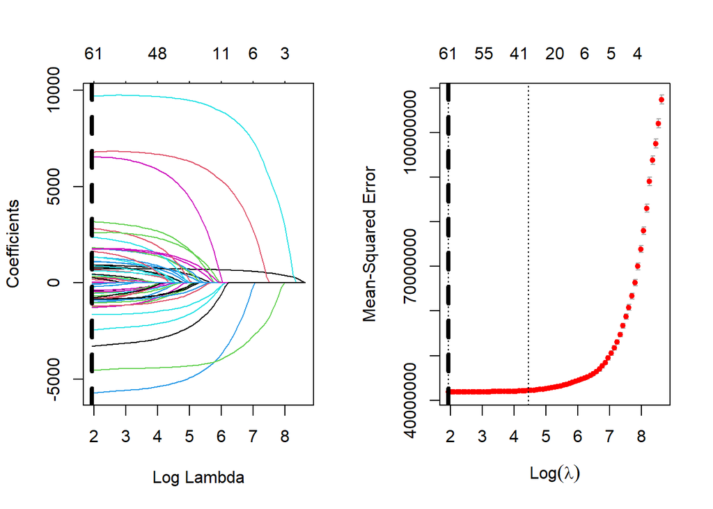

```r
lasso = glmnet(covariateMatrix,
               train$price,
               alpha=1)
#Now this matrix is obtained I will use the glmet package to obtain a cross validated ridge regression model from within the training data
#I will use 10 fold cross validation
cvLasso = cv.glmnet(covariateMatrix,
                    train$price,
                    alpha = 1,
                    nfolds = 10)

# lamda.min: value of lambda that minimises
# the cross-validation error
par(mfrow=c(1, 2))
plot(lasso, xvar="lambda")
abline(v=log(cvLasso$lambda.min), lwd=4, lty=2)
plot(cvLasso)
abline(v=log(cvLasso$lambda.min), lwd=4, lty=2)
```

```r
LassoPrediction = predict(cvLasso,newx=testMatrix)
lasso_rmse = sqrt(mean((LassoPrediction-test$price)**2))
```

#### Elastic Net

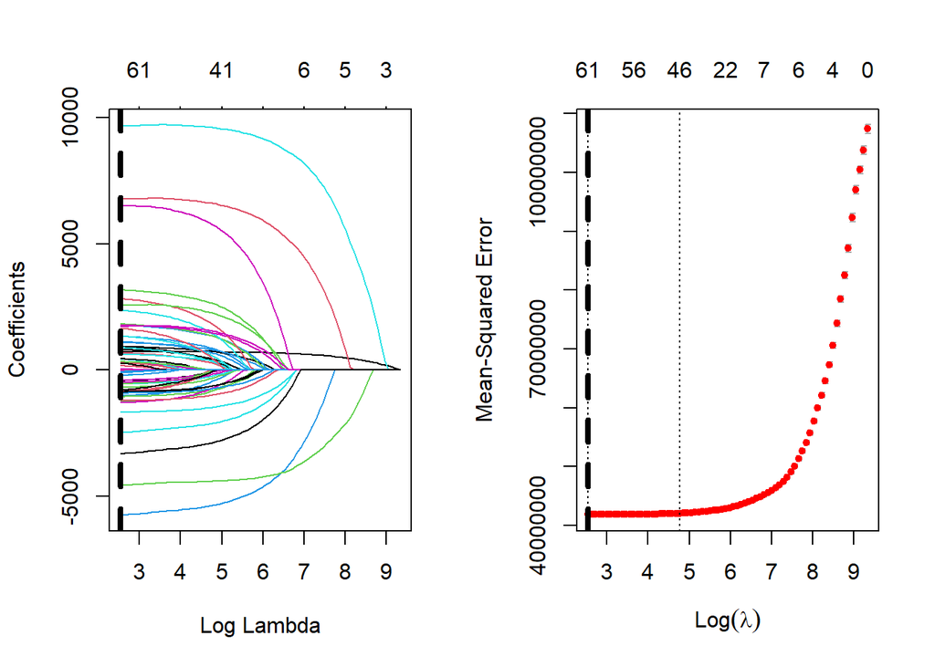

```r
a = 0.5 #Choosing an an alpha parameter for the weights of the ridge/lasso relationship
elastic = glmnet(covariateMatrix,
               train$price,
               alpha=a)
#Now this matrix is obtained I will use the glmet package to obtain a cross validated ridge regression model from within the training data
#I will use 10 fold cross validation
cvElastic = cv.glmnet(covariateMatrix,
                    train$price,
                    alpha = a,
                    nfolds = 10)

# lamda.min: value of lambda that minimises
# the cross-validation error
par(mfrow=c(1, 2))
plot(elastic, xvar="lambda")
abline(v=log(cvElastic$lambda.min), lwd=4, lty=2)
plot(cvElastic)
abline(v=log(cvElastic$lambda.min), lwd=4, lty=2)
```

```r
ElasticPrediction = predict(cvElastic,newx=testMatrix)
elastic_rmse = sqrt(mean((ElasticPrediction-test$price)**2))
```

#### GAM

```r
#Fitting a penalised regression spline model for the two numeric covariates with 10 knots

PRS_Model = mgcv::gam(price ~ splines::bs(odometer, knots = 10) + splines::bs(year, knots = 10) +state+type,
data=train)


prs_pred = predict(PRS_Model,newdata=test)
prs_rmse = sqrt(mean((prs_pred-test$price)**2))
```

#### Random Forest Model

1. Fitting a random forest model

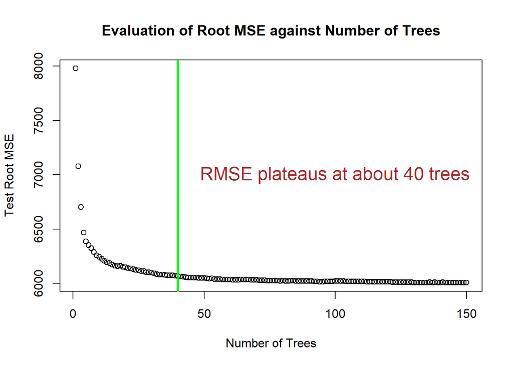

```r
#obtaining the prices from test data to compare the model to in the random forest
#Subsetting the data because it is quite large
rf_train = train[sample(nrow(train),
                     size = 10000),]

rf_test = test[sample(nrow(test),
                     size = 10000),]

testResponse = test$price
testCovariates = test %>%
  select(year, odometer, state, type)

# Testing the data on the random forest algorithm

rf1 = randomForest(price ~ year + odometer + state + type,
                          data = rf_train,
                          xtest = testCovariates,
                          ytest = testResponse,
                          mtry = 4,
                          ntree = 150,
                   do.trace = FALSE)
rf1_TE = sqrt(rf1$test$mse)
#Plotting the Root MSE against the number of trees to evaluate the point where returns begin to diminish
plot(rf1_TE,
     type = 'p',
     ylab = 'Test Root MSE',
     xlab = "Number of Trees",
     main = "Evaluation of Root MSE against Number of Trees")
abline(v = 40,
       col = 'green',
       lwd =3)
text(x = 100,
     y = 7000,
     "RMSE plateaus at about 40 trees",
     cex = 1.5,
     col = 'brown')
```

2. From the truncated model its pretty apparent we dont need so many trees, 25-50 ill say 40

```r
#Building Random Forest Model and Computing the RMSE

rf_model = randomForest(price ~ year + odometer + state + type,
                        data=train,
                        mtry = 4,
                        ntree = 40,
                        do.trace = FALSE)

rf_pred = predict(rf_model,newdata=test)
rf_rmse = sqrt(mean((rf_pred-test$price)**2))
```

## Conclusions

1. After running a number of models it is clear that the random forest model, based upon Root MSE our chosen generalisation error is the most suitable model for this analysis.

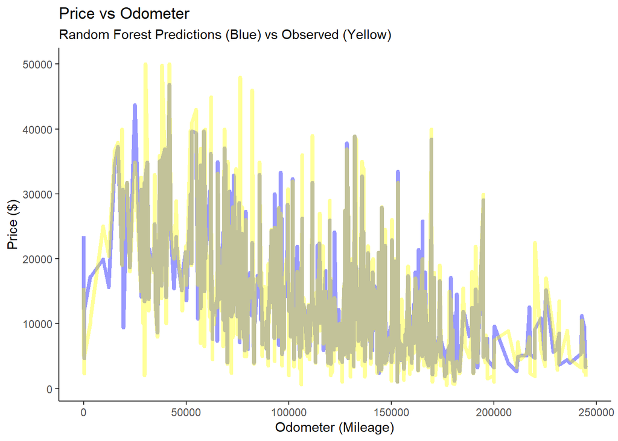

```r
set.seed(1934)
sample_comp = sample(length(rf_pred),
                     size = 500)
#Plotting an Example of Predictions vs Observed in a Selected 2 Dimensional Case
ggplot() + geom_line(aes(y = rf_pred[sample_comp],
                         x = test$odometer[sample_comp]),
                       color = 'blue',
                     size = 1.5,
            alpha = 0.4)+
  geom_line(aes(y = test$price[sample_comp],
                  x = test$odometer[sample_comp]),
              color = 'yellow',
            size = 1.5,
            alpha = 0.4)+
  labs(title = "Price vs Odometer",
       subtitle = "Random Forest Predictions (Blue) vs Observed (Yellow)",
       y = "Price ($)",
       x = "Odometer (Mileage)")+theme_classic()
```

```r
RMSE = as.data.frame(rbind("Random Forest" = rf_rmse,
      "Penalised Regression Spline" = prs_rmse,
      "Elastic Net Model" = elastic_rmse,
      "LASSO Model" = lasso_rmse,
      "Ridge Regression" = ridge_rmse,
      "Multiple Linear Regression" = lr_rmse))

colnames(RMSE) = "Root Mean Squared Error"

RMSE
```

```
##                             Root Mean Squared Error
## Random Forest                              5122.263
## Penalised Regression Spline                6261.475
## Elastic Net Model                          6519.284
## LASSO Model                                6530.457
## Ridge Regression                           6557.076
## Multiple Linear Regression                 6500.726
```

Though the error is quite large, if a two dimensional comparison is taken, the model fits the data quite well. Positive signs for the random forest model to continue development and push for better methods to minimize the generalization error.